# the_stars2

### Identifying the problem:

In this task, I seek to demonstrate how unsupervised learning machine leaning can be used in an unlabelled dataset.

`In this work`

The dataset contained different clusters of stars from some field. I will use clustering algorithm t attempts to find distinct groups of data without reference to any labels. A powerful clustering method called a Gaussian mixture model (GMM) will be adopted to achieve the goal.

```python
import pandas as pd
from IPython.display import display
import seaborn as sns
sns.set()
import matplotlib.pylab as plt
import warnings
warnings.filterwarnings('ignore')
%matplotlib inline
```

# Dataset

```python
df = pd.read_csv('data.csv')
```

Let's check the shape of the data

```python
df.shape
```

```
(18061, 160)
```

Let's impute missing values:

```python
print('\n---------------------------Impute missing values----------------------')
display(df.isnull().sum())
```

```
---------------------------Impute missing values----------------------
```

```
semester                                    0
FieldHalf                                   0
FIELD_1                                     0
Half                                        0
CHIP                                        0
RA_1                                      546
DEC_1                                     546
X_1                                       546
Y_1                                       546
MAG                                       546
MAGe                                      546
Name_1                                      0
Mean_Mag_1                                  0
RMS_1                                       0
Expected_RMS_1                              0
Alarm_2                                     0
Chi2_3                                      0
Jstet_4                                     0
Kurtosis_4                                  0
Lstet_4                                     0
LS_Period_1_5                               0
Log10_LS_Prob_1_5                           0
LS_SNR_1_5                                  0
Killharm_Mean_Mag_6                         0
Killharm_Per1_Fundamental_Sincoeff_6        0
Killharm_Per1_Fundamental_Coscoeff_6        0
Killharm_Per1_Amplitude_6                   0
Period_1_7                                  0
AOV_1_7                                     0
AOV_SNR_1_7                                 0
                                        ...
rmagAB                                  12476
e_rmag                                  12476
chir                                    12207
warningr                                12021
rmagap                                  12242
rmagapAB                                12242
e_rmagap                                12242
snrr                                    12220
rmaglim                                 12219
PSFFWHMr                                12021
MJDr                                    12021
detIDr                                  12021
cleani                                  12021
imag                                    12707
imagAB                                  12707
e_imag                                  12707
chii                                    12222
warningi                                12021
imagap                                  12252
imagapAB                                12252
e_imagap                                12252
snri                                    12222
imaglim                                 12220
PSFFWHMi                                12021
MJDi                                    12021
detIDi                                  12021
Field_2                                 12021
Ext                                     12021
nbDist                                  12021
Separation                              12021
Length: 160, dtype: int64
```

Here we will remove redundant columns from the dataset.

```python
df = df.iloc[:,5:34]

display(df.head(15))
```

|  | RA_1 | DEC_1 | X_1 | Y_1 | MAG | MAGe | Name_1 | Mean_Mag_1 | RMS_1 | Expected_RMS_1 | ... | Killharm_Per1_Fundamental_Sincoeff_6 | Killharm_Per1_Fundamental_Coscoeff_6 | Killharm_Per1_Amplitude_6 | Period_1_7 | AOV_1_7 | AOV_SNR_1_7 | AOV_NEG_LN_FAP_1_7 | RA2000 | DEC2000 | lspermin |
| --- | --- | --- | --- | --- | --- | --- | --- | --- | --- | --- | --- | --- | --- | --- | --- | --- | --- | --- | --- | --- | --- |
| 0 | 267.637420 | -32.505489 | 1309.394 | 117.711 | 11.6591 | 0.0026 | 100009 | 15.01506 | 0.01028 | 0.00179 | ... | 0.01155 | 0.00484 | 0.02505 | 0.015565 | 3.41553 | 4.67124 | 2.28794 | 17:50:33.0 | -32:30:19.8 | 113.177390 |
| 1 | 267.568298 | -32.472861 | 324.079 | 665.137 | 10.8853 | 0.0018 | 100218 | 14.18320 | 0.00339 | 0.00118 | ... | 0.00211 | 0.00338 | 0.00797 | 0.014812 | 5.02959 | 6.17483 | 4.81995 | 17:50:16.4 | -32:28:22.3 | 92.062210 |
| 2 | 267.555268 | -32.285918 | 126.340 | 3818.489 | 16.5748 | 0.0332 | 200510 | 20.58942 | 0.27845 | 0.05443 | ... | -0.26668 | -0.23009 | 0.70445 | 0.017541 | 5.07752 | 8.06232 | 4.88935 | 17:50:13.3 | -32:17:09.3 | 104.545224 |
| 3 | 267.758599 | -32.485136 | 886.993 | 462.508 | 17.1670 | 0.0503 | 100445 | 21.99514 | 0.18661 | 0.15743 | ... | -0.05318 | 0.15253 | 0.32307 | 0.007814 | 3.24337 | 3.98715 | 1.99459 | 17:51:02.1 | -32:29:06.5 | 18.891792 |
| 4 | 267.797234 | -32.472325 | 1436.175 | 679.620 | 12.2333 | 0.0034 | 100546 | 15.69679 | 0.00462 | 0.00248 | ... | -0.00545 | -0.00253 | 0.01201 | 0.006415 | 4.39385 | 4.75353 | 3.86889 | 17:51:11.3 | -32:28:20.4 | 71.308296 |
| 5 | 267.767202 | -32.368453 | 1003.500 | 2430.221 | 15.2115 | 0.0146 | 200327 | 18.97295 | 0.02625 | 0.01531 | ... | -0.00799 | -0.02875 | 0.05967 | 0.038873 | 4.48847 | 4.89371 | 3.91457 | 17:51:04.1 | -32:22:06.4 | 97.136510 |
| 6 | 267.768327 | -32.367157 | 1019.457 | 2452.106 | 16.0023 | 0.0231 | 200346 | 20.05330 | 0.05390 | 0.03288 | ... | -0.01641 | -0.05696 | 0.11855 | 0.010505 | 5.27810 | 6.39846 | 5.05030 | 17:51:04.4 | -32:22:01.8 | 92.754403 |
| 7 | 267.720869 | -32.337827 | 341.550 | 2945.095 | 16.4765 | 0.0312 | 200687 | 20.54297 | 0.05399 | 0.04898 | ... | 0.04113 | -0.03545 | 0.10859 | 0.017723 | 3.73648 | 4.71103 | 2.74842 | 17:50:53.0 | -32:20:16.2 | 31.794682 |
| 8 | 267.782309 | -32.314028 | 1216.120 | 3348.355 | 17.2033 | 0.0518 | 200950 | 21.85581 | 0.59356 | 0.12884 | ... | -0.57910 | -0.02658 | 1.15941 | 0.005993 | 3.53978 | 4.56843 | 2.42907 | 17:51:07.8 | -32:18:50.5 | 110.145859 |
| 9 | 267.835602 | -32.319098 | 1976.117 | 3264.169 | 17.4567 | 0.0626 | 200985 | 22.73157 | 0.33644 | 0.29747 | ... | -0.01420 | -0.29635 | 0.59337 | 0.006781 | 4.54292 | 6.00984 | 3.99572 | 17:51:20.5 | -32:19:08.8 | 8.191454 |
| 10 | 267.784256 | -32.303904 | 1243.385 | 3519.108 | 16.6806 | 0.0357 | 200831 | 22.14780 | 1.11575 | 0.40317 | ... | -0.31412 | -0.13794 | 0.68615 | 0.005668 | 9.63083 | 5.27875 | 10.05811 | 17:51:08.2 | -32:18:14.1 | 108.213480 |
| 11 | 267.850993 | -32.453306 | 57.513 | 997.950 | 12.4843 | 0.0038 | 101424 | 16.03348 | 0.00829 | 0.00286 | ... | -0.00380 | 0.00936 | 0.02021 | 0.011434 | 3.21058 | 4.05789 | 1.82369 | 17:51:24.2 | -32:27:11.9 | 99.660254 |
| 12 | 267.870488 | -32.362186 | 333.339 | 2535.851 | 15.7359 | 0.0212 | 200715 | 19.72227 | 0.02835 | 0.02617 | ... | 0.02391 | -0.02002 | 0.06237 | 0.006339 | 3.29613 | 3.83408 | 1.89724 | 17:51:28.9 | -32:21:43.9 | 12.498826 |
| 13 | 267.957741 | -32.282199 | 1576.479 | 3886.274 | 13.7495 | 0.0070 | 202052 | 17.41841 | 0.00899 | 0.00613 | ... | 0.00775 | 0.00741 | 0.02145 | 0.015871 | 4.35075 | 5.60937 | 3.50549 | 17:51:49.9 | -32:16:55.9 | 97.136510 |
| 14 | 267.956182 | -32.282561 | 1554.249 | 3880.173 | 16.3781 | 0.0324 | 201521 | 21.25057 | 0.40888 | 0.10962 | ... | -0.43060 | 0.14495 | 0.90868 | 0.034771 | 6.56148 | 7.70614 | 6.37014 | 17:51:49.5 | -32:16:57.2 | 91.380269 |

15 rows × 29 columns

Let's now check the shape of the data.

```python
df.shape
```

```
(18061, 29)
```

#### Removing all rows containing nans:

```python
display(df.isnull().sum())
```

```
RA_1                                    546
DEC_1                                   546
X_1                                     546
Y_1                                     546
MAG                                     546
MAGe                                    546
Name_1                                    0
Mean_Mag_1                                0
RMS_1                                     0
Expected_RMS_1                            0
Alarm_2                                   0
Chi2_3                                    0
Jstet_4                                   0
Kurtosis_4                                0
Lstet_4                                   0
LS_Period_1_5                             0
Log10_LS_Prob_1_5                         0
LS_SNR_1_5                                0
Killharm_Mean_Mag_6                       0
Killharm_Per1_Fundamental_Sincoeff_6      0
Killharm_Per1_Fundamental_Coscoeff_6      0
Killharm_Per1_Amplitude_6                 0
Period_1_7                                0
AOV_1_7                                   0
AOV_SNR_1_7                               0
AOV_NEG_LN_FAP_1_7                        0
RA2000                                  546
DEC2000                                 546
lspermin                                  0
dtype: int64
```

Let's drop all rows/samples containing nans:

```python
df = df.dropna()

df.shape
```

```
(17515, 29)
```

```python
display(df.head(10))
```

|  | RA_1 | DEC_1 | X_1 | Y_1 | MAG | MAGe | Name_1 | Mean_Mag_1 | RMS_1 | Expected_RMS_1 | ... | Killharm_Per1_Fundamental_Sincoeff_6 | Killharm_Per1_Fundamental_Coscoeff_6 | Killharm_Per1_Amplitude_6 | Period_1_7 | AOV_1_7 | AOV_SNR_1_7 | AOV_NEG_LN_FAP_1_7 | RA2000 | DEC2000 | lspermin |
| --- | --- | --- | --- | --- | --- | --- | --- | --- | --- | --- | --- | --- | --- | --- | --- | --- | --- | --- | --- | --- | --- |
| 0 | 267.637420 | -32.505489 | 1309.394 | 117.711 | 11.6591 | 0.0026 | 100009 | 15.01506 | 0.01028 | 0.00179 | ... | 0.01155 | 0.00484 | 0.02505 | 0.015565 | 3.41553 | 4.67124 | 2.28794 | 17:50:33.0 | -32:30:19.8 | 113.177390 |
| 1 | 267.568298 | -32.472861 | 324.079 | 665.137 | 10.8853 | 0.0018 | 100218 | 14.18320 | 0.00339 | 0.00118 | ... | 0.00211 | 0.00338 | 0.00797 | 0.014812 | 5.02959 | 6.17483 | 4.81995 | 17:50:16.4 | -32:28:22.3 | 92.062210 |
| 2 | 267.555268 | -32.285918 | 126.340 | 3818.489 | 16.5748 | 0.0332 | 200510 | 20.58942 | 0.27845 | 0.05443 | ... | -0.26668 | -0.23009 | 0.70445 | 0.017541 | 5.07752 | 8.06232 | 4.88935 | 17:50:13.3 | -32:17:09.3 | 104.545224 |
| 3 | 267.758599 | -32.485136 | 886.993 | 462.508 | 17.1670 | 0.0503 | 100445 | 21.99514 | 0.18661 | 0.15743 | ... | -0.05318 | 0.15253 | 0.32307 | 0.007814 | 3.24337 | 3.98715 | 1.99459 | 17:51:02.1 | -32:29:06.5 | 18.891792 |
| 4 | 267.797234 | -32.472325 | 1436.175 | 679.620 | 12.2333 | 0.0034 | 100546 | 15.69679 | 0.00462 | 0.00248 | ... | -0.00545 | -0.00253 | 0.01201 | 0.006415 | 4.39385 | 4.75353 | 3.86889 | 17:51:11.3 | -32:28:20.4 | 71.308296 |
| 5 | 267.767202 | -32.368453 | 1003.500 | 2430.221 | 15.2115 | 0.0146 | 200327 | 18.97295 | 0.02625 | 0.01531 | ... | -0.00799 | -0.02875 | 0.05967 | 0.038873 | 4.48847 | 4.89371 | 3.91457 | 17:51:04.1 | -32:22:06.4 | 97.136510 |
| 6 | 267.768327 | -32.367157 | 1019.457 | 2452.106 | 16.0023 | 0.0231 | 200346 | 20.05330 | 0.05390 | 0.03288 | ... | -0.01641 | -0.05696 | 0.11855 | 0.010505 | 5.27810 | 6.39846 | 5.05030 | 17:51:04.4 | -32:22:01.8 | 92.754403 |
| 7 | 267.720869 | -32.337827 | 341.550 | 2945.095 | 16.4765 | 0.0312 | 200687 | 20.54297 | 0.05399 | 0.04898 | ... | 0.04113 | -0.03545 | 0.10859 | 0.017723 | 3.73648 | 4.71103 | 2.74842 | 17:50:53.0 | -32:20:16.2 | 31.794682 |
| 8 | 267.782309 | -32.314028 | 1216.120 | 3348.355 | 17.2033 | 0.0518 | 200950 | 21.85581 | 0.59356 | 0.12884 | ... | -0.57910 | -0.02658 | 1.15941 | 0.005993 | 3.53978 | 4.56843 | 2.42907 | 17:51:07.8 | -32:18:50.5 | 110.145859 |
| 9 | 267.835602 | -32.319098 | 1976.117 | 3264.169 | 17.4567 | 0.0626 | 200985 | 22.73157 | 0.33644 | 0.29747 | ... | -0.01420 | -0.29635 | 0.59337 | 0.006781 | 4.54292 | 6.00984 | 3.99572 | 17:51:20.5 | -32:19:08.8 | 8.191454 |

10 rows × 29 columns

We still have three redundant columns, let's remove them:

```python
x = df.drop(['RA2000','DEC2000', 'Name_1'], axis = 1)

print('\n-----------------------------------Shape of the dataset---------------------------------')
display(x.shape)
```

```
-----------------------------------Shape of the dataset---------------------------------
```

```
(17515, 26)
```

For 2-dimensional subspace: The first principal component (PCA1) covers the maximum variance in the data and the second principal component (PCA2) is orthogonal to the first principal component--all principal components are orthogonal to each other.

A vital part of using PCA in practice is the ability to estimate how many components are needed to describe the data. The cumulative explained variance technique, which measures how well PCA preserves the content of the data will be employed.

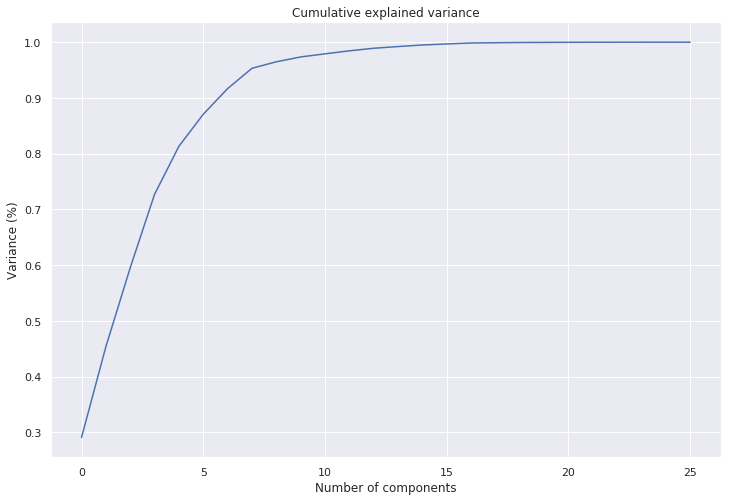

```python
from sklearn.decomposition import PCA
from sklearn.preprocessing import MinMaxScaler
import numpy as np

data_rescaled = MinMaxScaler().fit_transform(x)

pca = PCA().fit(data_rescaled)

plt.figure(figsize=(12,8))
plt.plot(np.cumsum(pca.explained_variance_ratio_))

plt.xlabel('Number of components')
plt.ylabel('Variance (%)') #for each component
plt.title('Cumulative explained variance')
```

Here we see that our two-dimensional projection will lose a lot of information (as measured by the explained variance) and that we’d need about 6 components to retain about 90$\%$ of the variance.

`We will convert our dataset to two dimension:`

```python
model = PCA(n_components = 2).fit(x)  #project from 29 to 2 dimensions

x_2D = model.transform(x) #Transform the data to two dimensions
```

```python
x['PCA1'] = x_2D[:, 0]
x['PCA2'] = x_2D[:, 1]
```

```python
display(x.head(10))
```

|  | RA_1 | DEC_1 | X_1 | Y_1 | MAG | MAGe | Mean_Mag_1 | RMS_1 | Expected_RMS_1 | Alarm_2 | ... | Killharm_Per1_Fundamental_Sincoeff_6 | Killharm_Per1_Fundamental_Coscoeff_6 | Killharm_Per1_Amplitude_6 | Period_1_7 | AOV_1_7 | AOV_SNR_1_7 | AOV_NEG_LN_FAP_1_7 | lspermin | PCA1 | PCA2 |
| --- | --- | --- | --- | --- | --- | --- | --- | --- | --- | --- | --- | --- | --- | --- | --- | --- | --- | --- | --- | --- | --- |
| 0 | 267.637420 | -32.505489 | 1309.394 | 117.711 | 11.6591 | 0.0026 | 15.01506 | 0.01028 | 0.00179 | 6.39196 | ... | 0.01155 | 0.00484 | 0.02505 | 0.015565 | 3.41553 | 4.67124 | 2.28794 | 113.177390 | 1948.591969 | 337.968307 |
| 1 | 267.568298 | -32.472861 | 324.079 | 665.137 | 10.8853 | 0.0018 | 14.18320 | 0.00339 | 0.00118 | 5.10836 | ... | 0.00211 | 0.00338 | 0.00797 | 0.014812 | 5.02959 | 6.17483 | 4.81995 | 92.062210 | 1419.477850 | -657.317068 |
| 2 | 267.555268 | -32.285918 | 126.340 | 3818.489 | 16.5748 | 0.0332 | 20.58942 | 0.27845 | 0.05443 | 7.80936 | ... | -0.26668 | -0.23009 | 0.70445 | 0.017541 | 5.07752 | 8.06232 | 4.88935 | 104.545224 | -1729.683459 | -913.293074 |
| 3 | 267.758599 | -32.485136 | 886.993 | 462.508 | 17.1670 | 0.0503 | 21.99514 | 0.18661 | 0.15743 | 0.66387 | ... | -0.05318 | 0.15253 | 0.32307 | 0.007814 | 3.24337 | 3.98715 | 1.99459 | 18.891792 | 1611.715190 | -90.758327 |
| 4 | 267.797234 | -32.472325 | 1436.175 | 679.620 | 12.2333 | 0.0034 | 15.69679 | 0.00462 | 0.00248 | 3.85503 | ... | -0.00545 | -0.00253 | 0.01201 | 0.006415 | 4.39385 | 4.75353 | 3.86889 | 71.308296 | 1384.455794 | 454.317422 |
| 5 | 267.767202 | -32.368453 | 1003.500 | 2430.221 | 15.2115 | 0.0146 | 18.97295 | 0.02625 | 0.01531 | 5.04427 | ... | -0.00799 | -0.02875 | 0.05967 | 0.038873 | 4.48847 | 4.89371 | 3.91457 | 97.136510 | -357.867313 | -10.641048 |
| 6 | 267.768327 | -32.367157 | 1019.457 | 2452.106 | 16.0023 | 0.0231 | 20.05330 | 0.05390 | 0.03288 | 2.51186 | ... | -0.01641 | -0.05696 | 0.11855 | 0.010505 | 5.27810 | 6.39846 | 5.05030 | 92.754403 | -380.040359 | 4.908457 |
| 7 | 267.720869 | -32.337827 | 341.550 | 2945.095 | 16.4765 | 0.0312 | 20.54297 | 0.05399 | 0.04898 | 1.10537 | ... | 0.04113 | -0.03545 | 0.10859 | 0.017723 | 3.73648 | 4.71103 | 2.74842 | 31.794682 | -860.374826 | -681.993746 |
| 8 | 267.782309 | -32.314028 | 1216.120 | 3348.355 | 17.2033 | 0.0518 | 21.85581 | 0.59356 | 0.12884 | 10.07342 | ... | -0.57910 | -0.02658 | 1.15941 | 0.005993 | 3.53978 | 4.56843 | 2.42907 | 110.145859 | -1279.778915 | 184.983958 |
| 9 | 267.835602 | -32.319098 | 1976.117 | 3264.169 | 17.4567 | 0.0626 | 22.73157 | 0.33644 | 0.29747 | -0.58983 | ... | -0.01420 | -0.29635 | 0.59337 | 0.006781 | 4.54292 | 6.00984 | 3.99572 | 8.191454 | -1209.589339 | 946.396651 |

10 rows × 28 columns

# Visualise data in 2D

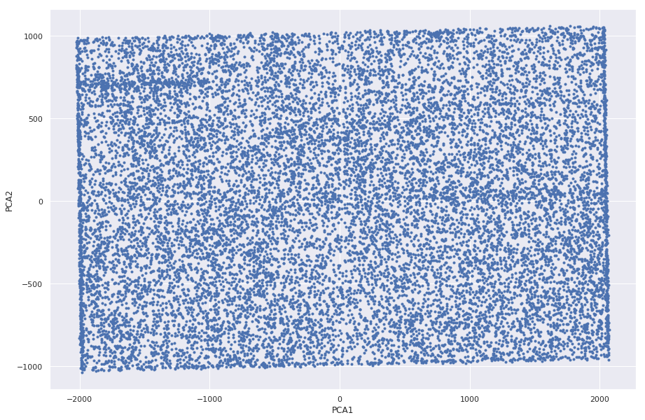

```python
plt.figure(figsize=(15,10))
plt.scatter(x['PCA1'], x['PCA2'], marker = '.')


plt.xlabel('PCA1')
plt.ylabel('PCA2')
```

Clearly, we see that 2D doesn't give much information.

### Let's consider two clusterring algorithms (KMeans & Gaussian Mixture):

We will instantiates different algorithms

# 1. K-Means

```python
from sklearn import preprocessing
from sklearn.pipeline import Pipeline

from sklearn.cluster import KMeans
```

## Optimal number of clusters and cluster evaluation:

We shall use `the elbow method` to determine the optimal number of clusters in k-means clustering.

```python
from scipy.spatial.distance import cdist, pdist
import numpy as np
# Avg. within-cluster sum of squares

#
K = np.arange(1, 15)

model1 = [KMeans(n_clusters = k).fit(data_rescaled) for k in K]

#centroids
cent_ = [k.cluster_centers_ for k in model1]

#Compute distance between each pair of the two collections of inputs
D_k = [cdist(data_rescaled, centrds, 'euclidean') for centrds in cent_]

#compute minimum distance to each centroid
dist = [np.min(D, axis = 1) for D in D_k]

#average distance within cluster-sum
avgWithinSS = [sum(d)/data_rescaled.shape[0] for d in dist]
```

`Let's view elbow curve`:

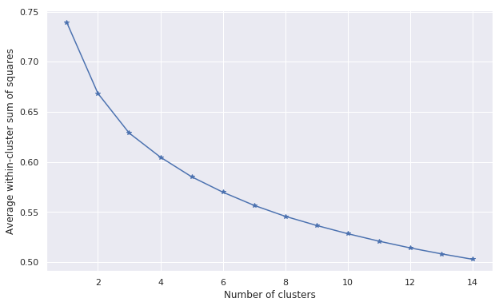

```python
# elbow curve - Avg. within-cluster sum of squares

plt.figure(figsize = (10,6))
plt.plot(K, avgWithinSS, 'b*-')
plt.xlabel('Number of clusters')
plt.ylabel('Average within-cluster sum of squares')
```

The elbow seemed to be located at k = 3.

```python
kmeans = Pipeline(steps=[('preprocessor', preprocessing.StandardScaler()),
                     ('model', KMeans(n_clusters = 3, n_init = 1, random_state = 10))])

model1 = kmeans.fit(x)

y_kmeans = model1.predict(x)

x['clusterKM'] = y_kmeans

x.clusterKM.unique()
```

```
array([0, 2, 1])
```

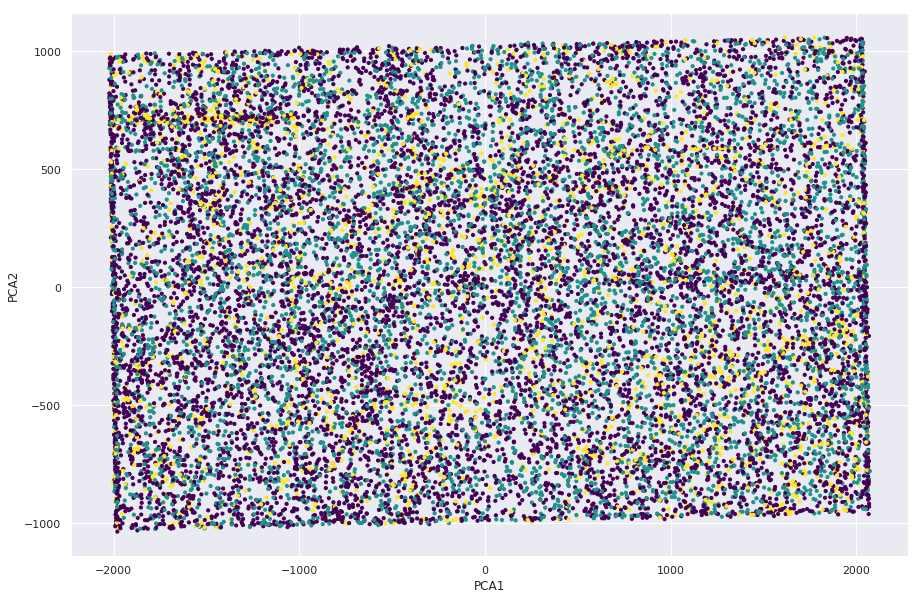

```python
plt.figure(figsize=(15,10))

plt.scatter(x['PCA1'], x['PCA2'], marker = '.', c = y_kmeans, s = 40, cmap = 'viridis')


plt.xlabel('PCA1')
plt.ylabel('PCA2')
```

```
0    9622
1    5550
2    2343
Name: clusterKM, dtype: int64
```

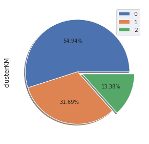

```python
display(x['clusterKM'].value_counts())

#x.clusterGMM.value_counts().plot('bar')


x['clusterKM'].value_counts().plot(kind = 'pie',
                                 explode=(0,0,0.1), autopct='%1.2f%%',
                                 shadow=True,
                                 legend = True, figsize= (6,4), labels=None)

plt.tight_layout()
```

## 2 Gaussian Mixture Model:

```python
from sklearn.mixture import GaussianMixture
```

### Selecting the number of components in a classical Gaussian Mixture Mode.

We shall use the Bayesian information criterion (BIC) to select the number of components in a Gaussian Mixture in an efficient way.

```
BIC for number of cluster(s) 1: -1676190.6216027052
Log-likelihood score for number of cluster(s) 1: 47.95530168653835
----------------------------------------------------------------------------------------------------
BIC for number of cluster(s) 2: -2171325.82039032
Log-likelihood score for number of cluster(s) 2: 62.195340683891565
----------------------------------------------------------------------------------------------------
BIC for number of cluster(s) 3: -2300437.126170328
Log-likelihood score for number of cluster(s) 3: 65.98651034046242
----------------------------------------------------------------------------------------------------
BIC for number of cluster(s) 4: -2328548.6398803927
Log-likelihood score for number of cluster(s) 4: 66.89444299817677
----------------------------------------------------------------------------------------------------
BIC for number of cluster(s) 5: -2380433.2167969383
Log-likelihood score for number of cluster(s) 5: 68.48102433435189
----------------------------------------------------------------------------------------------------
BIC for number of cluster(s) 6: -2397149.4573575854
Log-likelihood score for number of cluster(s) 6: 69.06365658814336
----------------------------------------------------------------------------------------------------
BIC for number of cluster(s) 7: -2417503.796183502
Log-likelihood score for number of cluster(s) 7: 69.75014548667563
----------------------------------------------------------------------------------------------------
BIC for number of cluster(s) 8: -2445254.568869919
Log-likelihood score for number of cluster(s) 8: 70.64778008490818
----------------------------------------------------------------------------------------------------
BIC for number of cluster(s) 9: -2437824.68070565
Log-likelihood score for number of cluster(s) 9: 70.54111377390045
----------------------------------------------------------------------------------------------------
```

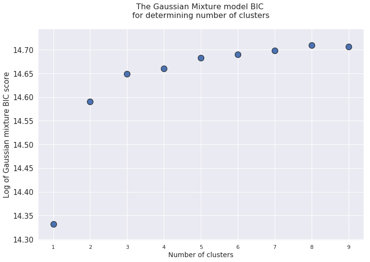

```python
gm_bic= []
gm_score=[]

for i in range(1,10):

    gm = GaussianMixture(n_components = i, n_init = 1, tol = 1e-6, max_iter = 1000, random_state = 10).fit(data_rescaled)

    print("BIC for number of cluster(s) {}: {}".format(i,gm.bic(data_rescaled)))
    print("Log-likelihood score for number of cluster(s) {}: {}".format(i,gm.score(data_rescaled)))
    print("-"*100)

    gm_bic.append(-gm.bic(data_rescaled))
    gm_score.append(gm.score(data_rescaled))



plt.figure(figsize = (12,8))
plt.title("The Gaussian Mixture model BIC \nfor determining number of clusters\n",fontsize=16)
plt.scatter(x = [i for i in range(1,10)],y = np.log(gm_bic), s = 150, edgecolor='k')
plt.xlabel("Number of clusters",fontsize = 14)
plt.ylabel("Log of Gaussian mixture BIC score",fontsize = 15)
plt.yticks(fontsize = 15)
plt.show()
```

```python
from sklearn import preprocessing
from sklearn.pipeline import Pipeline
import warnings
warnings.filterwarnings('ignore')



GMM = Pipeline(steps = [('preprocessor', preprocessing.StandardScaler()),
                     ('model', GaussianMixture(n_components = 3, covariance_type = 'full'))])

#assigning feature matrix to a new variable
xx = x

model = GMM.fit(xx)

#print(model.score(x))

y_gmm = model.predict(xx)

xx['clusterGMM'] = y_gmm
```

`Let's view our 2D figure:`

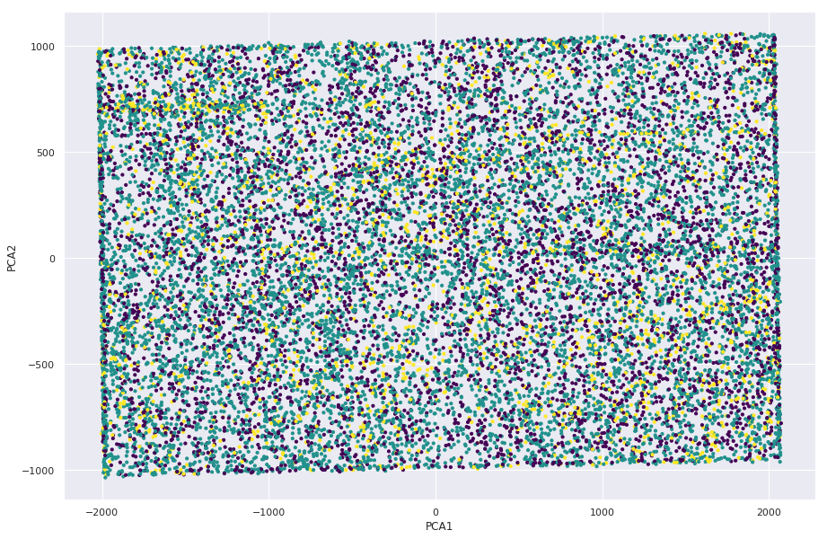

```python
plt.figure(figsize=(15,10))

plt.scatter(xx['PCA1'], xx['PCA2'], marker = '.', c = y_gmm, s = 40, cmap = 'viridis')


plt.xlabel('PCA1')
plt.ylabel('PCA2')
```

```
1    9622
0    5550
2    2343
Name: clusterGMM, dtype: int64
```

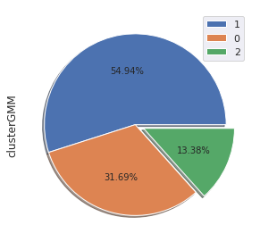

```python
display(xx.clusterGMM.value_counts())

#x.clusterGMM.value_counts().plot('bar')


xx['clusterGMM'].value_counts().plot(kind = 'pie',
                                 explode=(0,0,0.1), autopct='%1.2f%%',
                                 shadow=True,
                                 legend = True, figsize= (6,4), labels=None)

plt.tight_layout()
```

```python
display(xx.head(8))
```

|  | RA_1 | DEC_1 | X_1 | Y_1 | MAG | MAGe | Mean_Mag_1 | RMS_1 | Expected_RMS_1 | Alarm_2 | ... | Killharm_Per1_Amplitude_6 | Period_1_7 | AOV_1_7 | AOV_SNR_1_7 | AOV_NEG_LN_FAP_1_7 | lspermin | PCA1 | PCA2 | clusterKM | clusterGMM |
| --- | --- | --- | --- | --- | --- | --- | --- | --- | --- | --- | --- | --- | --- | --- | --- | --- | --- | --- | --- | --- | --- |
| 0 | 267.637420 | -32.505489 | 1309.394 | 117.711 | 11.6591 | 0.0026 | 15.01506 | 0.01028 | 0.00179 | 6.39196 | ... | 0.02505 | 0.015565 | 3.41553 | 4.67124 | 2.28794 | 113.177390 | 1948.591969 | 337.968307 | 0 | 1 |
| 1 | 267.568298 | -32.472861 | 324.079 | 665.137 | 10.8853 | 0.0018 | 14.18320 | 0.00339 | 0.00118 | 5.10836 | ... | 0.00797 | 0.014812 | 5.02959 | 6.17483 | 4.81995 | 92.062210 | 1419.477850 | -657.317068 | 0 | 1 |
| 2 | 267.555268 | -32.285918 | 126.340 | 3818.489 | 16.5748 | 0.0332 | 20.58942 | 0.27845 | 0.05443 | 7.80936 | ... | 0.70445 | 0.017541 | 5.07752 | 8.06232 | 4.88935 | 104.545224 | -1729.683459 | -913.293074 | 2 | 2 |
| 3 | 267.758599 | -32.485136 | 886.993 | 462.508 | 17.1670 | 0.0503 | 21.99514 | 0.18661 | 0.15743 | 0.66387 | ... | 0.32307 | 0.007814 | 3.24337 | 3.98715 | 1.99459 | 18.891792 | 1611.715190 | -90.758327 | 1 | 0 |
| 4 | 267.797234 | -32.472325 | 1436.175 | 679.620 | 12.2333 | 0.0034 | 15.69679 | 0.00462 | 0.00248 | 3.85503 | ... | 0.01201 | 0.006415 | 4.39385 | 4.75353 | 3.86889 | 71.308296 | 1384.455794 | 454.317422 | 0 | 1 |
| 5 | 267.767202 | -32.368453 | 1003.500 | 2430.221 | 15.2115 | 0.0146 | 18.97295 | 0.02625 | 0.01531 | 5.04427 | ... | 0.05967 | 0.038873 | 4.48847 | 4.89371 | 3.91457 | 97.136510 | -357.867313 | -10.641048 | 0 | 1 |
| 6 | 267.768327 | -32.367157 | 1019.457 | 2452.106 | 16.0023 | 0.0231 | 20.05330 | 0.05390 | 0.03288 | 2.51186 | ... | 0.11855 | 0.010505 | 5.27810 | 6.39846 | 5.05030 | 92.754403 | -380.040359 | 4.908457 | 0 | 1 |
| 7 | 267.720869 | -32.337827 | 341.550 | 2945.095 | 16.4765 | 0.0312 | 20.54297 | 0.05399 | 0.04898 | 1.10537 | ... | 0.10859 | 0.017723 | 3.73648 | 4.71103 | 2.74842 | 31.794682 | -860.374826 | -681.993746 | 1 | 0 |

8 rows × 30 columns

```python
from IPython.display import HTML

HTML('<iframe width="560" height="315" src="//www.youtube.com/embed/byQrdnq7_H0" frameborder="0" allowfullscreen></iframe>')
```